# Homework 3

You Peng

2022-03-07

## APIs

#### Using the NCBI API, look for papers that show up under the term “sars-cov-2 vaccine.” Look for the data in the pubmed database, and then retrieve the details of the paper as shown in the lab. How many papers were you able to find?

```
## [1] "18,566"
```

```
## [1] "18438"
```

#### Using the list of pubmed ids you retrieved, download the details of each paper using the query parameter rettype = abstract. If you get more than 250 ids, just keep the first 250.

We will first obtain the ids of papers:

```r
# Turn the result into a character vector
ids <- as.character(ids)

# Find all the ids
ids <- stringr::str_extract_all(ids, "<Id>[1-9]+</Id>")[[1]]

# Remove all the leading and trailing <Id> </Id>. Make use of "|"
ids <- stringr::str_remove_all(ids, "<Id>|</Id>")
ids <- ids[1:250]
```

We will then use these ids to get our papers:

```r
publications <- GET(
  url   = "https://eutils.ncbi.nlm.nih.gov/entrez/eutils/efetch.fcgi",
  query = list(
    db = "pubmed",
    id = paste(ids, collapse=","),
    retmax = 250,
    rettype = "abstract"

  )
)

# Turning the output into character vector
publications <- httr::content(publications)
publications_txt <- as.character(publications)
```

The details of first 250 papers are stored in publications_txt.

#### Create a dataset

We want to build a dataset which includes: 1. Pubmed ID number, 2. Title of the paper, 3. Name of the journal where it was published, 4. Publication date, and 5. Abstract of the paper (if any)

First separate our papers and store them in a list,

then extract the abstracts of papers:

```r
abstracts <- stringr::str_extract(pub_char_list, "<Abstract>(\\n|.)+</Abstract>")
abstracts <- str_remove_all(abstracts, "</?[[:alpha:]]+>")
abstracts <- str_replace_all(abstracts, "\\s+", " ")
table(is.na(abstracts))
```

```
##
## FALSE  TRUE
##   227    23
```

Then the titles of papers:

```r
titles <- stringr::str_extract(pub_char_list, "<ArticleTitle>(\\n|.)+</ArticleTitle>")
titles <- str_remove_all(titles, "</?[[:alnum:]]+>")
titles <- str_replace_all(titles, "\\s+", " ")
table(is.na(titles))
```

```
##
## FALSE
##   250
```

Then names of the journals where each paper was published:

```r
journals <- stringr::str_extract(pub_char_list, "<Title>(\\n|.)+</Title>")
journals <- str_remove_all(journals, "</?[[:alnum:]]+>")
journals <- str_replace_all(journals, "\\s+", " ")
table(is.na(journals))
```

```
##
## FALSE
##   250
```

Then Publication dates:

```r
dates <- stringr::str_extract(pub_char_list, "<PubDate>(\\n|.)+</PubDate>")
dates <- str_remove_all(dates, "</?[[:alnum:]]+>")
dates <- str_replace_all(dates, "\\s+", " ")
table(is.na(dates))
```

```
##
## FALSE
##   250
```

Finally, put everything together into a single `data.frame` and use `knitr::kable` to print the results

| PubMedId | Title | Journals | Date | Abstract |
| --- | --- | --- | --- | --- |
| 35254412 | Hypersensitivity Reactions to COVID-19 Vaccines-Identify High-Risk Children and Vaccinate the Rest. | JAMA pediatrics | 2022 Mar 07 | NA |
| 35254219 | Adverse Events of Special Interest Following the Use of BNT162b2 in Adolescents: A Population-Based Retrospective Cohort Study. | Emerging microbes & infections | 2022 Mar 07 | Accruing evidence suggests an increased risk of myocarditis in adolescents from messenger RNA COVID-19 vaccines. However, other potential adverse events remain under-researched. We conducted a retrosp… |
| 35254213 | VITT with inactivated SARS-CoV-2 vaccine - index case. | Human vaccines & immunotherapeutics | 2022 Mar 07 | We report a case of vaccine-induced immune thrombotic thrombocytopenia (VITT) in a 73-year-old gentleman who presented with pulmonary embolism and thrombocytopenia, two weeks after receiving inactivat… |
| 35254166 | Comparative 6-Month Wild-Type and Delta-Variant Antibody Levels and Surrogate Neutralization for Adults Vaccinated with BNT162b2 versus mRNA-1273. | Microbiology spectrum | 2022 Mar 07 | While mRNA vaccines are highly efficacious against short-term COVID-19, long-term immunogenicity is less clear. We compared humoral immunogenicity between BNT162b2 and mRNA-1273 vaccines 6 months afte… |
| 35254122 | Correlation Analysis between Gut Microbiota Alterations and the Cytokine Response in Patients with Coronavirus Disease during Hospitalization. | Microbiology spectrum | 2022 Mar 07 | The role of the intestinal microbiota in coronavirus disease 2019 (COVID-19) is being elucidated. Here, we analyzed the temporal changes in microbiota composition and the correlation between inflammat… |
| 35253789 | Dynamic Monitoring of Seroconversion using a Multianalyte Immunobead Assay for Covid-19. | Journal of visualized experiments : JoVE | 2022 Feb 16 | Multiplex technologies for interrogating multiple biomarkers in concert have existed for several decades; however, methods to evaluate multiple epitopes on the same analyte remain limited. This report… |
| 35253346 | Coronavirus disease 2019 and vaccination in patients with Shwachman-Diamond syndrome. | Pediatric blood & cancer | 2022 Mar 06 | Because they can experience neutropenia due to bone marrow failure, patients with Shwachman-Diamond syndrome (SDS) carry increased risk for serious infections compared with the general population; how… |
| 35253229 | Augmented Neutralization of SARS-CoV-2 Omicron Variant by Boost Vaccination and Monoclonal Antibodies. | European journal of immunology | 2022 Mar 06 | Effective vaccines and monoclonal antibodies have been developed against coronavirus disease 2019 (COVID-19) caused by severe acute respiratory syndrome coronavirus 2 (SARS-CoV-2). However, the appear… |
| 35252935 | A highly immunogenic live-attenuated vaccine candidate prevents SARS-CoV-2 infection and transmission in hamsters. | Innovation (New York, N.Y.) | 2022 Mar 02 | The highly pathogenic and readily transmissible SARS-CoV-2 has caused a global coronavirus pandemic, urgently requiring effective countermeasures against its rapid expansion. All available vaccine pla… |
| 35252837 | COVID-19 susceptibility and vaccination coverage for measles, rubella and mumps in students and healthcare workers in Trieste hospitals (NE Italy). | Vaccine: X | 2022 Apr | Measles, mumps, and rubella (MMR) vaccines have been suggested as preventive measures to protect subjects from the worst sequelae of COVID-19 infection because neutralizing antibodies can cross-react … |
| 35252469 | Tacrolimus-resistant SARS-CoV-2-specific T-cell products to prevent and treat severe COVID-19 in immunosuppressed patients. | Molecular therapy. Methods & clinical development | 2022 Feb 26 | Solid organ transplant (SOT) recipients receive therapeutic immunosuppression that compromises their immune response to infections and vaccines. For this reason, SOT patients have a high risk of devel… |
| 35252231 | Randomized, Double Blind, Placebo Controlled, Clinical Trial to Study Ashwagandha Administration in Participants Vaccinated Against COVID-19 on Safety, Immunogenicity, and Protection With COVID-19 Vac… | Frontiers in medicine | 2022 | Vaccines have emerged as the most effective tool in the fight against COVID-19. Governments all over the world have rolled out the COVID-19 vaccine program for their populations. Oxford-AstraZeneca CO… |
| 35251817 | Seasonal and 2009 Pandemic H1N1 Vaccine Acceptance as a Predictor for COVID-19 Vaccine Acceptance. | Cureus | 2022 Jan | The emergence of COVID-19 also began an unprecedented production and distribution of several novel COVID-19 vaccines to combat the pandemic. Unfortunately, with the history of vaccine hesitancy in the… |
| 35251812 | COVID-19 Vaccine-Related Myocarditis: A Descriptive Study of 40 Case Reports. | Cureus | 2022 Jan | After the surging rise in the Coronavirus disease 2019 (COVID-19) pandemic, the Food and Drug Administration (FDA) approved emergency approval of vaccinations to prevent life-threatening complications… |
| 35251795 | Comorbidities and Vaccination Status of COVID-19 All-Cause Mortality at a Tertiary Care Center of Western India. | Cureus | 2022 Jan | COVID-19 vaccines have been found to be efficacious for preventing severe disease, yet breakthrough infections and deaths have occurred in a small proportion of vaccinated individuals. This study aime… |
| 35251762 | Pixel-based analysis of pulmonary changes on CT lung images due to COVID-19 pneumonia. | Journal of clinical imaging science | 2022 | Objectives: Computed tomography (CT) plays a complementary role in the diagnosis of the pneumonia-burden of COVID-19 disease. However, the low contrast of areas of inflammation on CT images, areas of … |
| 35251658 | Presumed oculomotor nerve palsy following COVID-19 vaccination. | SAGE open medical case reports | 2022 | We herein report the case of an 84-year-old female who presented to the outpatient clinic one day following her first dose of the Pfizer-BioNTech COVID-19 vaccine with mydriasis, ptosis, and a “down a… |
| 35251522 | MALDI-TOF mass spectrometry of saliva samples as a prognostic tool for COVID-19. | Journal of oral microbiology | 2022 | The SARS-CoV-2 infections are still imposing a great public health challenge despite the recent developments in vaccines and therapy. Searching for diagnostic and prognostic methods that are fast, low… |
| 35249775 | Social media use and vaccine hesitancy in the European Union. | Vaccine | 2022 Mar 03 | Vaccine hesitancy can hinder the successful roll-out of vaccines. This paper examines COVID-19 vaccine hesitancy in the European Union, drawing from a large-scale cross-national survey covering all 27… |
| 35249774 | How do COVID-19 vaccine mandates affect attitudes toward the vaccine and participation in mandate-affected activities? Evidence from the United States. | Vaccine | 2022 Mar 02 | The spread of COVID-19 has prompted many governments, schools, and companies to institute vaccine mandates. Proponents suggest that mandates will enhance public health and increase vaccination rates. … |
| 35249675 | Modifying SARS-CoV-2 vaccine schedule in Spain: When numbers matters. | Enfermedades infecciosas y microbiologia clinica (English ed.) | 2022 03 | NA |
| 35249568 | Variations in COVID-19 vaccination uptake among people in receipt of psychotropic drugs: cross-sectional analysis of a national population-based prospective cohort. | The British journal of psychiatry : the journal of mental science | 2022 Mar 07 | Coronavirus disease 2019 (COVID-19) has disproportionately affected people with mental health conditions. We investigated the association between receiving psychotropic drugs, as an indicator of menta… |
| 35249484 | The Immune Response to SARS-CoV-2: Mechanisms, Aging, Sequelae and Vaccines. | Mini reviews in medicinal chemistry | 2022 Mar 04 | This review seeks to clarify the factors involved in the various immune responses to SARS-CoV-2 infection and the mechanisms that influence the development of COVID-19 with severe evolution. The innat… |
| 35249377 | Immunity to SARS-CoV-2: What Do We Know and Should We Be Testing for It? | Journal of clinical microbiology | 2022 Mar 07 | Preexisting immunity to Severe Acute Respiratory Syndrome Coronavirus-2 (SARS-CoV-2) was nonexistent in humans, which coupled with high transmission rates of certain SARS-CoV-2 variants and limited va… |
| 35249272 | Covid-19 Vaccine Effectiveness against the Omicron (B.1.1.529) Variant. | The New England journal of medicine | 2022 Mar 02 | A rapid increase in coronavirus disease 2019 (Covid-19) cases due to the omicron (B.1.1.529) variant of severe acute respiratory syndrome coronavirus 2 in highly vaccinated populations has aroused con… |
| 35249187 | On the Frontline-A bibliometric Study on Sustainability, Development, Coronaviruses, and COVID-19. | Environmental science and pollution research international | 2022 Mar 06 | The COVID-19 pandemic has placed the world’s population in a state of unprecedented public health and global health vulnerability. Risks to public and global health have escalated due to COVID-19 cont… |
| 35248745 | Assessment of BIV1-CovIran inactivated vaccine-elicited neutralizing antibody against the emerging SARS-CoV-2 variants of concern. | Clinical microbiology and infection : the official publication of the European Society of Clinical Microbiology and Infectious Diseases | 2022 Mar 03 | BIV1-CovIran vaccine is highly effective against COVID-19. The neutralizing potency of all SARS-CoV-2 vaccines seems to be decreased against the variants of concern (VOCs). We assessed the sensitivity… |
| 35248659 | Role of Genomics in combating COVID-19 pandemic. | Gene | 2022 Mar 03 | The coronavirus disease 2019 (COVID-19) quickly swept over the world, becoming one of the most devastating outbreaks in human history. Being the first pandemic in the post-genomic era, advancements in… |
| 35248424 | Monitoring COVID-19 vaccine use in Italian long term care centers: The GeroCovid VAX study. | Vaccine | 2022 Feb 22 | The COVID-19 pandemic has changed routine care practice for older persons, especially in those with frailty living in long term care (LTC) facilities. Due to the high mortality rates of Nursing home (… |
| 35248422 | WHO guidance on COVID-19 vaccine trial designs in the context of authorized COVID-19 vaccines and expanding global access: Ethical considerations. | Vaccine | 2022 Feb 28 | While the degree of COVID-19 vaccine accessibility and uptake varies at both national and global levels, increasing vaccination coverage raises questions regarding the standard of prevention that ough… |

[output cut: 220 more lines]

There are 250 rows and 5 columns in the database.

```
## [1] 250   5
```

## Text Mining

First take a look at the most frequent tokens appear in abstracts:

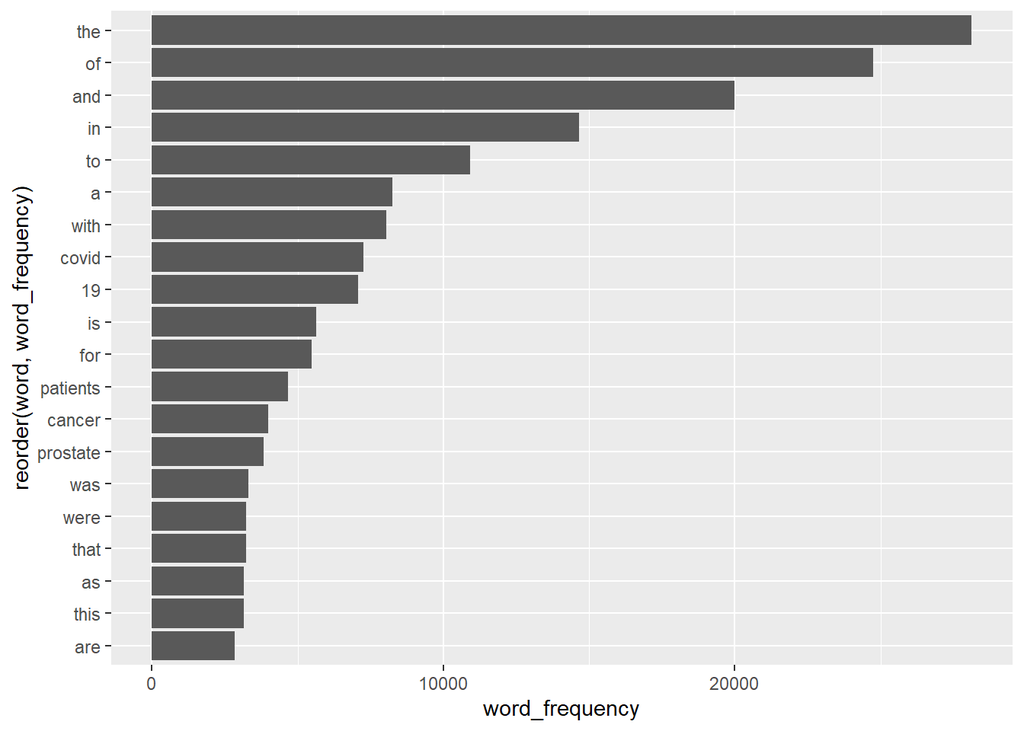

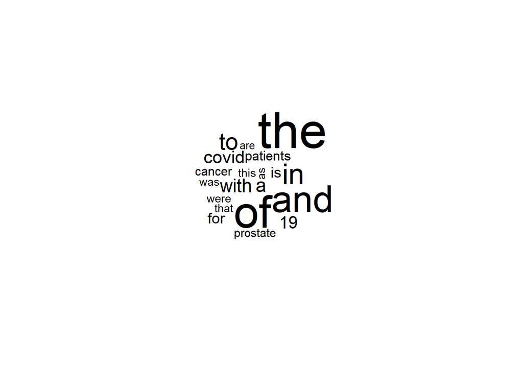

We can see that some stopwords appear to be the most frequent ones in abstracts of papers. For example, words such as “the”, “of”, “and”, “to”, and “in” are the five most frequent ones. Meanwhile, words such as “covid”, “patients”, and “cancer” also appear in the top 20 frequent words list. These words did tell us some information about what these papers are about.

Then we are going to take a look at the most frequent tokens in abstracts after removing all stopwords:

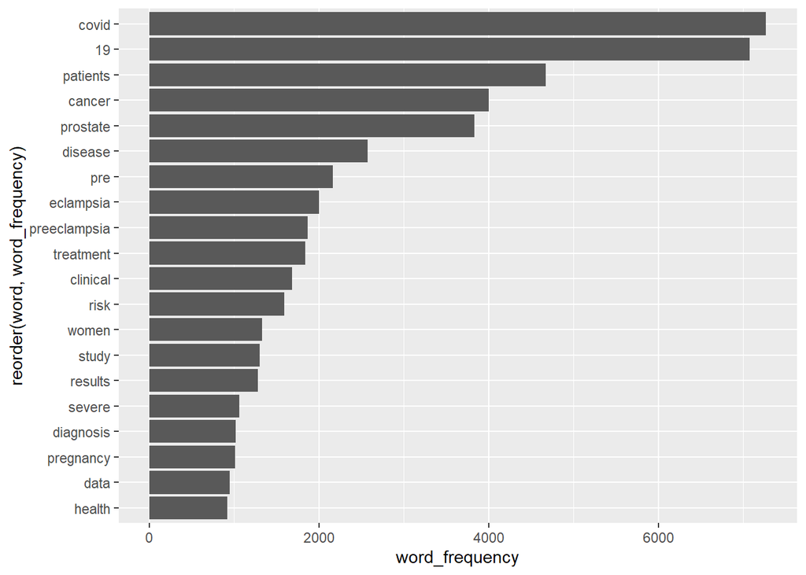

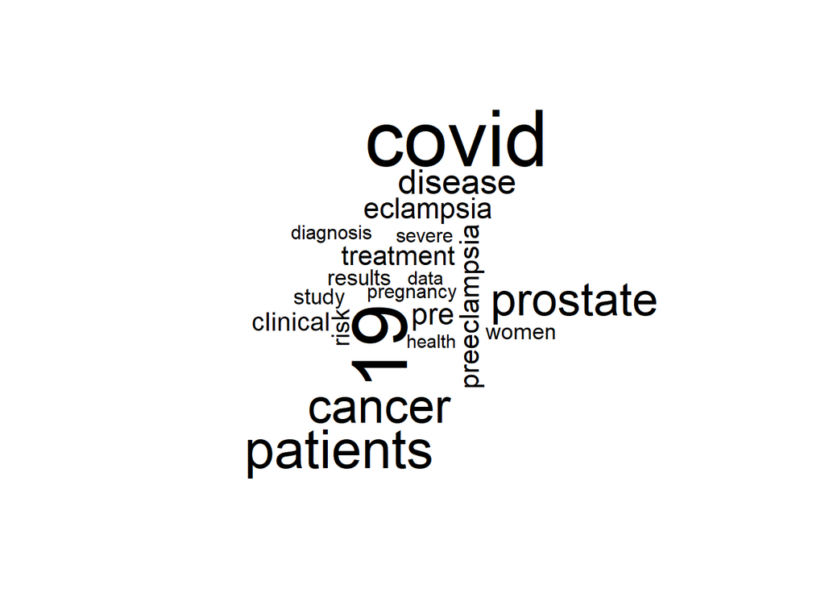

We see that words such as “covid”, “19”, “patients”, “cancer”, and “prostate” become the top 5 most frequent words in abstracts. It’s also interesting to see that the word “covid” and “19” have close frequencies, and the word “cancer” and “prostate” have close frequencies. This may suggest that these words tend to appear in pairs. We can explore more about these bi-grams by tokenizing the abstract into bi-grams and count them. We can also see some of our search terms such as “covid”, “prostate cancer”, and “preeclampsia” appear in the top 20 frequent words list. Generally speaking, after we removing stopwords, the list of frequent words appear to contain more information about the papers, we can infer what these papers are about by looking at these frequent tokens.

#### We will present five most common tokens for each search term after removing stop-words.

```
##              term
## 1           covid
## 2      meningitis
## 3 prostate cancer
## 4 cystic fibrosis
## 5    preeclampsia
```

```
##            word            term    n
## 1         covid           covid 7271
## 2            19           covid 7035
## 3      patients           covid 2293
## 4       disease           covid  943
## 5      pandemic           covid  800
## 6      fibrosis cystic fibrosis  867
## 7        cystic cystic fibrosis  862
## 8            cf cystic fibrosis  625
## 9      patients cystic fibrosis  586
## 10      disease cystic fibrosis  400
## 11     patients      meningitis  446
## 12   meningitis      meningitis  429
## 13    meningeal      meningitis  219
## 14          csf      meningitis  206
## 15     clinical      meningitis  187
## 16          pre    preeclampsia 2038
## 17    eclampsia    preeclampsia 1998
## 18 preeclampsia    preeclampsia 1863
## 19        women    preeclampsia 1196
## 20    pregnancy    preeclampsia  969
## 21       cancer prostate cancer 3840
## 22     prostate prostate cancer 3832
## 23     patients prostate cancer  934
## 24    treatment prostate cancer  926
## 25      disease prostate cancer  652
```

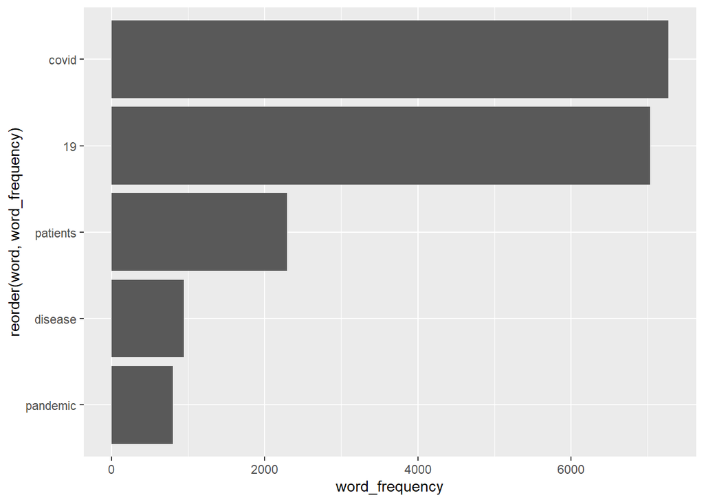

```r
tokens <- df %>% filter(term=="covid") %>% unnest_tokens(word, abstract) %>% anti_join(stop_words, by="word") %>% group_by(word) %>% summarize(word_frequency = n()) %>% arrange(across(word_frequency, desc)) %>% head(5)

tokens %>% ggplot(aes(x=reorder(word, word_frequency), y=word_frequency)) + geom_bar(stat='identity') + coord_flip()
```

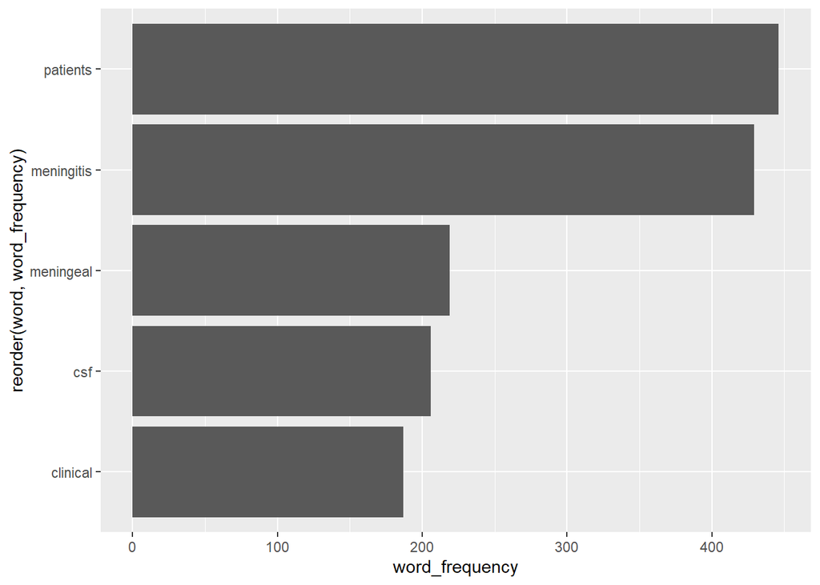

```r
tokens <- df %>% filter(term=="meningitis") %>% unnest_tokens(word, abstract) %>% anti_join(stop_words, by="word") %>% group_by(word) %>% summarize(word_frequency = n()) %>% arrange(across(word_frequency, desc)) %>% head(5)

tokens %>% ggplot(aes(x=reorder(word, word_frequency), y=word_frequency)) + geom_bar(stat='identity') + coord_flip()
```

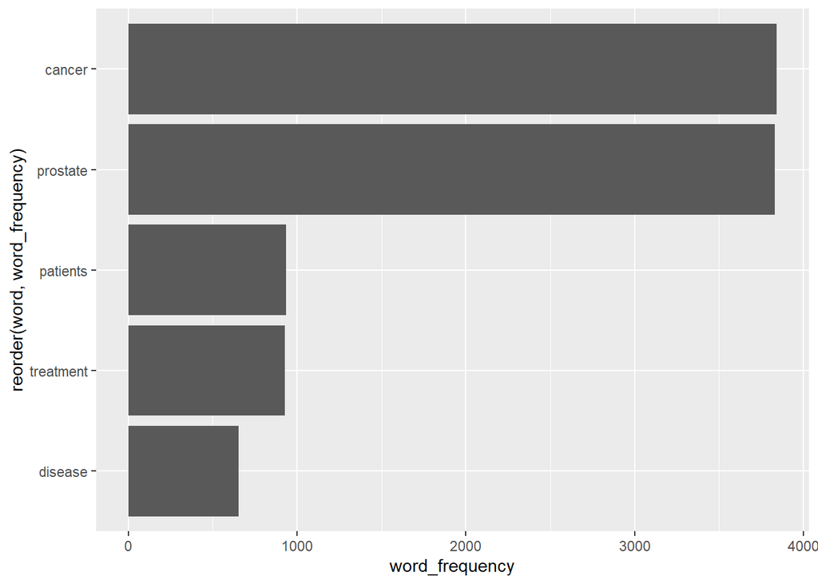

```r
tokens <- df %>% filter(term=="prostate cancer") %>% unnest_tokens(word, abstract) %>% anti_join(stop_words, by="word") %>% group_by(word) %>% summarize(word_frequency = n()) %>% arrange(across(word_frequency, desc)) %>% head(5)

tokens %>% ggplot(aes(x=reorder(word, word_frequency), y=word_frequency)) + geom_bar(stat='identity') + coord_flip()
```

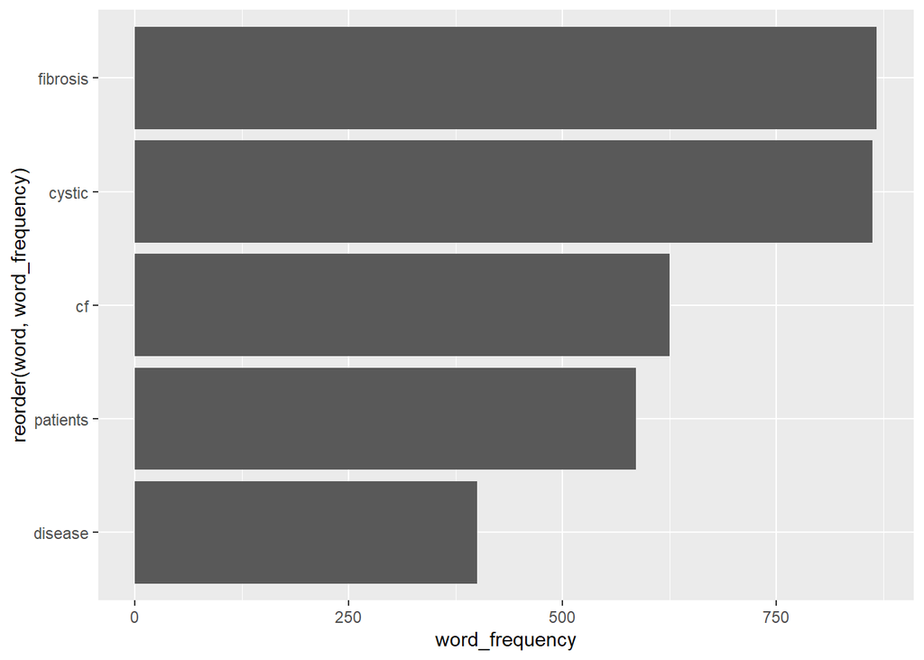

```r
tokens <- df %>% filter(term=="cystic fibrosis") %>% unnest_tokens(word, abstract) %>% anti_join(stop_words, by="word") %>% group_by(word) %>% summarize(word_frequency = n()) %>% arrange(across(word_frequency, desc)) %>% head(5)

tokens %>% ggplot(aes(x=reorder(word, word_frequency), y=word_frequency)) + geom_bar(stat='identity') + coord_flip()
```

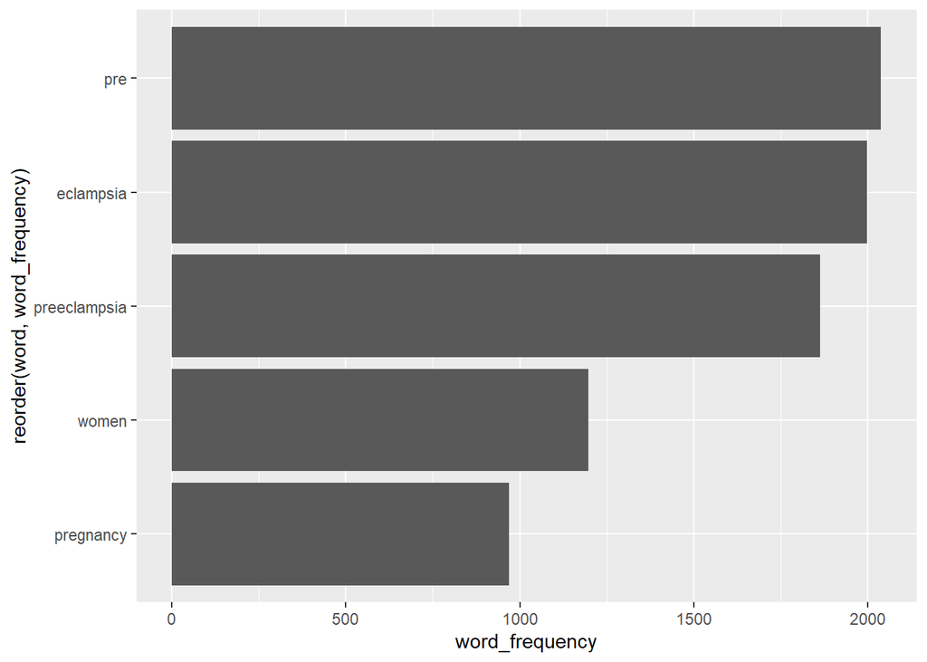

```r
tokens <- df %>% filter(term=="preeclampsia") %>% unnest_tokens(word, abstract) %>% anti_join(stop_words, by="word") %>% group_by(word) %>% summarize(word_frequency = n()) %>% arrange(across(word_frequency, desc)) %>% head(5)

tokens %>% ggplot(aes(x=reorder(word, word_frequency), y=word_frequency)) + geom_bar(stat='identity') + coord_flip()
```

#### Next, we are going to tokenize the abstracts into bigrams. Here are 10 most common bigram and their visualization.

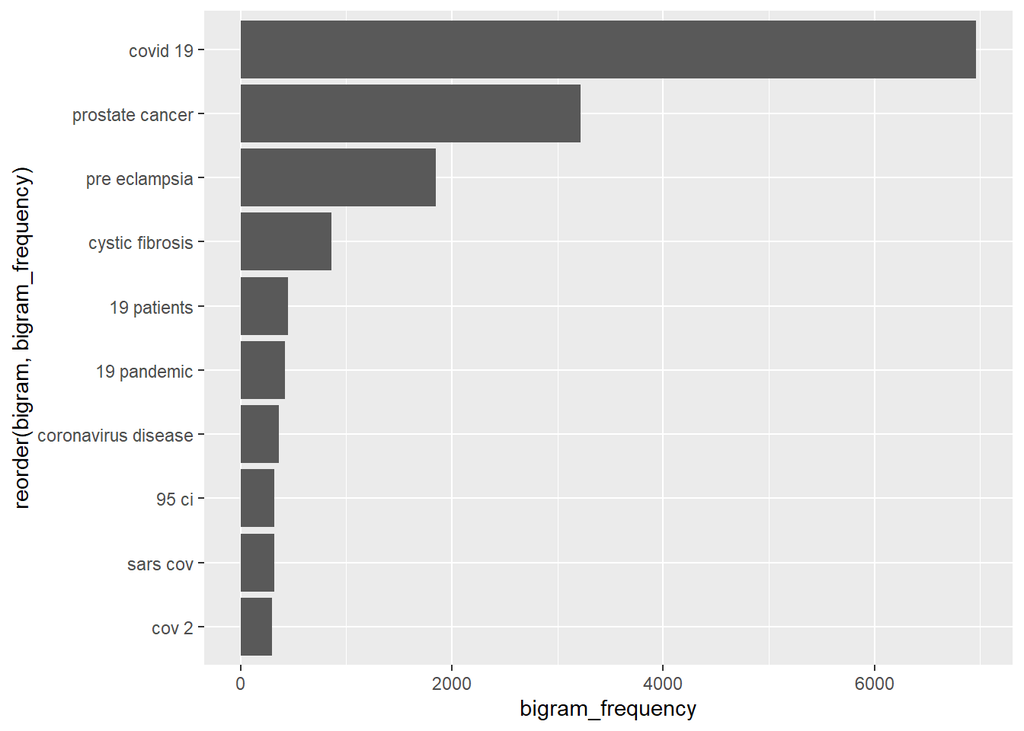

From the visualization, we can see that the bigram “covid 19” appears over 6500 times, which is the most frequently appeared bigram in papers. We can also see that “sars cov” and “cov 2” are close in their frequencies, this may indicates that they usually comes in the form of tri-grams. Moreover, “prostate cancer” did appear as a frequent bi-gram. These conclusions match up with our previous prediction on bigrams. Lastly, we can see that our search term “cystic fibrosis” also appears on the list.

#### Lastly, we will calculate the TF-IDF value for each word-search term combination.

```
##               word            term    n          tf       idf      tf_idf
## 1            covid           covid 7271 0.064487805 1.6094379 0.103789118
## 2         pandemic           covid  800 0.007095344 1.6094379 0.011419515
## 3      coronavirus           covid  647 0.005738359 1.6094379 0.009235533
## 4             sars           covid  372 0.003299335 1.6094379 0.005310075
## 5              cov           covid  333 0.002953437 1.6094379 0.004753373
## 6               cf cystic fibrosis  625 0.023400352 0.9162907 0.021441526
## 7         fibrosis cystic fibrosis  867 0.032460968 0.5108256 0.016581894
## 8           cystic cystic fibrosis  862 0.032273765 0.5108256 0.016486266
## 9             cftr cystic fibrosis   86 0.003219888 1.6094379 0.005182211
## 10           sweat cystic fibrosis   83 0.003107567 1.6094379 0.005001436
## 11      meningitis      meningitis  429 0.016373421 1.6094379 0.026352004
## 12       meningeal      meningitis  219 0.008358460 1.6094379 0.013452422
## 13 pachymeningitis      meningitis  149 0.005686806 1.6094379 0.009152561
## 14             csf      meningitis  206 0.007862295 0.9162907 0.007204148
## 15        meninges      meningitis  106 0.004045647 1.6094379 0.006511218
## 16       eclampsia    preeclampsia 1998 0.025388515 1.6094379 0.040861239
## 17    preeclampsia    preeclampsia 1863 0.023673075 1.6094379 0.038100345
## 18       pregnancy    preeclampsia  969 0.012313049 0.5108256 0.006289821
## 19        maternal    preeclampsia  797 0.010127451 0.5108256 0.005173361
## 20     gestational    preeclampsia  191 0.002427030 1.6094379 0.003906155
## 21        prostate prostate cancer 3832 0.056244588 1.6094379 0.090522172
## 22        androgen prostate cancer  305 0.004476670 1.6094379 0.007204922
## 23             psa prostate cancer  282 0.004139085 1.6094379 0.006661600
## 24   prostatectomy prostate cancer  215 0.003155685 1.6094379 0.005078880
## 25      castration prostate cancer  148 0.002172286 1.6094379 0.003496159
```

The result are different from question 1. For term “covid”, tokens “coronavirus”, “sars”, and “cov” have replaced “19”, “patient”, “disease”. For term “cystic fibrosis”, tokens “cftr”, “sweat” have replaced “patient”, “disease”. For term “meningitis”, tokens “pachymeningitis”, “meninges” have replaced “patient”, “clinical”. For term “preeclampsia”, tokens “maternal”, “gestational” have replaced “women”, “pre”. For term “prostate cancer”, tokens “androgen”, “psa”, “prostatectomy”, and “castration” have replaced “cancer”, “patient”, “disease”, “treatment”. This is reasonable, since we can see that the word “patient” appears in all papers from different search term, this makes it less representative under each search term and has a smaller ti-idf value in each search term. Similar reason applies to other words that are replaced. The 5 tokens from each search term with the highest TF-IDF value are now the most representative ones under each search term.